# Projekt 1

Mateusz Wroblewski

5/7/2022

**Zadanie 1**

Zaczynamy od wczytania niezbędnych bibliotek oraz importu danych.

```r
library(ggplot2)
library(GGally)
library(dplyr)
library(jmuOutlier)
library(lmtest)
```

Następnie wczytujemy dane i poddajemy je podstawowej analizie

```r
ludzie <- read.csv("~/Desktop/studia2/stat/people.tab.csv", sep="", header=T)
str(ludzie)
```

```
## 'data.frame':    500 obs. of  9 variables:
##  $ wiek         : int  25 37 41 43 26 49 27 49 38 33 ...
##  $ waga         : num  61.7 63.9 50.2 72.4 78.4 59.4 67.5 82.3 64.1 77.4 ...
##  $ wzrost       : num  121 145 145 180 164 ...
##  $ plec         : Factor w/ 2 levels "K","M": NA 2 1 2 2 1 2 1 1 2 ...
##  $ stan_cywilny : logi  FALSE TRUE TRUE FALSE FALSE TRUE ...
##  $ liczba_dzieci: int  2 6 2 1 1 2 1 0 5 2 ...
##  $ budynek      : Factor w/ 5 levels "apartament","jednorodzinny",..: 4 5 1 5 1 4 2 5 5 1 ...
##  $ wydatki      : num  1663 4042 3853 2399 2344 ...
##  $ oszczednosci : num  23.4 96.8 312.7 447.4 -78.2 ...
```

```r
summary(ludzie)
```

```
##       wiek            waga            wzrost        plec     stan_cywilny
##  Min.   :17.00   Min.   : 45.20   Min.   :113.6   K   :239   Mode :logical
##  1st Qu.:33.00   1st Qu.: 59.20   1st Qu.:155.6   M   :223   FALSE:327
##  Median :39.00   Median : 67.50   Median :169.0   NA's: 38   TRUE :173
##  Mean   :39.48   Mean   : 68.03   Mean   :168.2
##  3rd Qu.:45.00   3rd Qu.: 75.60   3rd Qu.:180.1
##  Max.   :72.00   Max.   :107.20   Max.   :235.2
##  liczba_dzieci            budynek       wydatki        oszczednosci
##  Min.   :0.000   apartament   : 54   Min.   : 524.9   Min.   :-685.68
##  1st Qu.:0.750   jednorodzinny:187   1st Qu.:1807.0   1st Qu.:  74.52
##  Median :1.000   kamienica    :105   Median :2489.9   Median : 402.22
##  Mean   :1.558   loft         : 54   Mean   :2511.7   Mean   : 478.60
##  3rd Qu.:2.000   wielka_plyta :100   3rd Qu.:3084.5   3rd Qu.: 802.73
##  Max.   :6.000                       Max.   :5574.6   Max.   :3503.90
```

```r
sapply(ludzie, function(x) sum(is.na(x)))
```

```
##          wiek          waga        wzrost          plec  stan_cywilny
##             0             0             0            38             0
## liczba_dzieci       budynek       wydatki  oszczednosci
##             0             0             0             0
```

Jak widać, mamy 500 obserwacji 6 zmiennych ilościowych - wiek, waga, wzrost, liczba dzieci, wydatki i oszczędności - oraz 3 zmiennych jakościowych - płeć, stan cywilny i budynek. Wystepują nieduże braki w danych - 38 obserwacji nie ma podanej płci. Obejrzyjmy teraz nasze dane wizualnie.

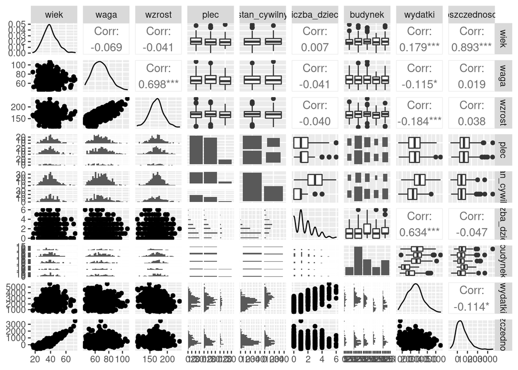

```r
ggpairs(ludzie)
```

Jak widać, występują zależności między niektórymi danymi, silną korelację możemy zaobserwować między innymi pomiędzy wagą i wzrostem oraz wiekiem i oszczędnościami. Powyższe wykresy moglibyśmy zaprezentować z podziałem na płeć, jednak stają się mniej czytelne a nie pozwalają zaobserwować istotnych zależności.

**Zadanie 2**

Teraz spróbujmy przyjżeć się bliżej naszym danym.

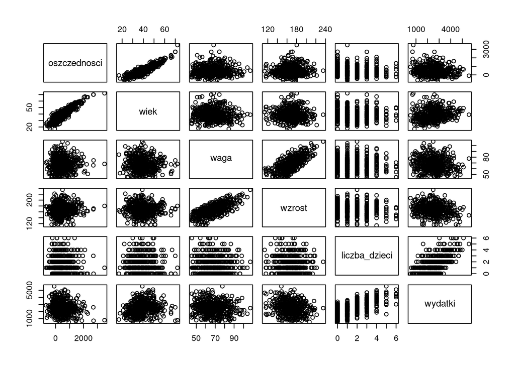

```r
pairs(oszczednosci ~ . , data=ludzie[unlist(lapply(ludzie, is.numeric))])
```

Widzimy, tak jak poprzednio, silną zależność między oszczędnościami a wiekiem oraz między wagą a wzrostem. Więkoszość pozostałych wykresów tworzy “chmury” danych. Poza wykresami liczby dzieci, które z oczywistych przyczyn skupiają się na małym zbiorze wartości.

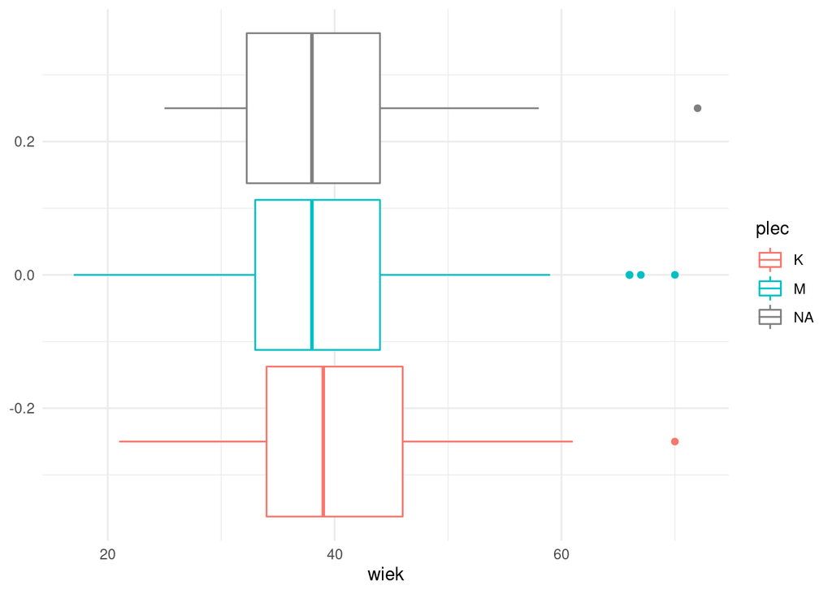

```r
ggplot(data=ludzie) + geom_boxplot(aes(x=wiek, col=plec)) + theme_minimal()
```

Wykres przedstawia wykres wieku respondentów w zależności od ich płci. Dostrzegamy wysokie podobieństwo wykresów pudełkowych, z nieznacznie wyższą medianą oraz kwartylami dla kobiet niż dla mężczyznych oraz 3 odstającymi obserwacjami dla mężczyzn przeciwko tylko jednej takiej obserwacji dla kobiet.

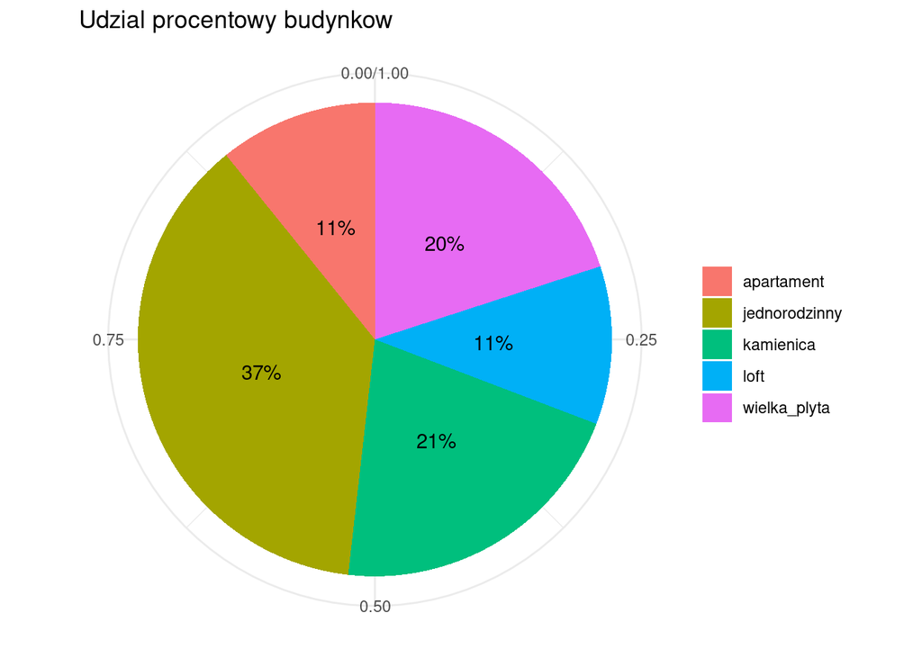

```r
procent <- ludzie %>%
  group_by(budynek) %>%
  summarise(count = n() / nrow(.) )
ggplot(procent, aes(x="", y=count, fill=budynek)) + geom_bar(stat="identity", width=1)+ coord_polar("y") + geom_text(aes(label = paste0(round(count*100), "%")), position = position_stack(vjust = 0.5))+ labs(x = NULL, y = NULL, fill = NULL, title = "Udzial procentowy budynkow")+theme_minimal()
```

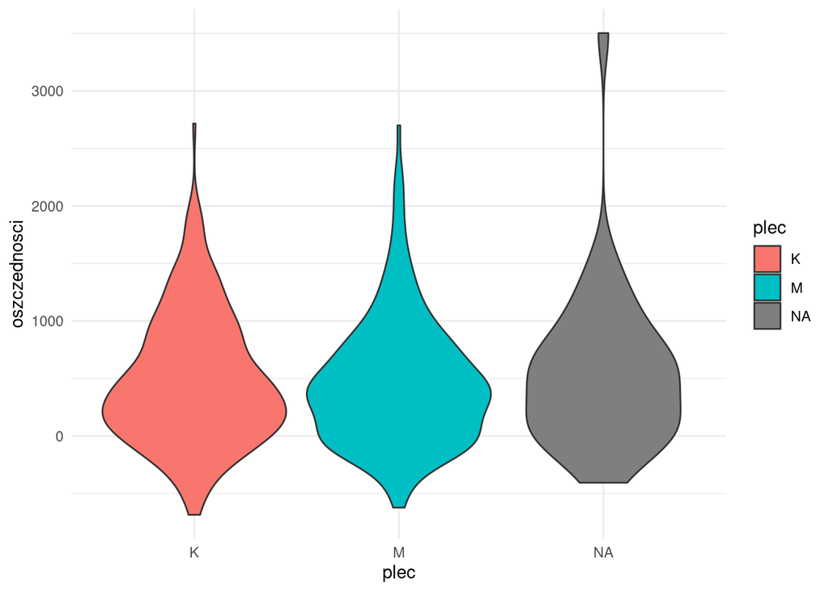

```r
ggplot(ludzie, aes(x=plec, y=oszczednosci, fill=plec)) + geom_violin() +theme_minimal()
```

Wykres przedstawia rozkład oszczędności w zależności od płci respondentów. Widzimy wyraźne podobieństwo otrzymanych rozkładów.

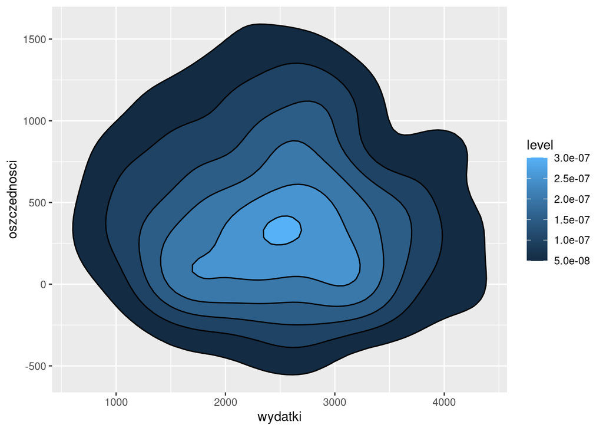

```r
ggplot(ludzie, aes(x=wydatki, y=oszczednosci) ) +  stat_density_2d(aes(fill = ..level..), geom = "polygon", colour="black")
```

Na powyższym wykresie widzimy “mapę ciepła”, czyli pokolorowany po gęstości wykres typu scatter-plot oszczędności od wydatków. Najczęstszym przypadkiem są wydatki rzędu około 2500 dla oszczędności rzędu około 350, i w miarę oddalania się od tych wartości ilość obserwacji maleje.

**Zadanie 3**

Chcemy znaleźć p-wartości dla hipotezy $H_0:m_e = 165 $ dla zmiennej wzrost przeciwko hipotezie alternatywnej $H_0<165$. W tym celu chcielibyśmy skorzystać z testu Wilcoxona, ale aby to zrobić musimy upewnić się że nasze dane są rozłożone symetrycznie.

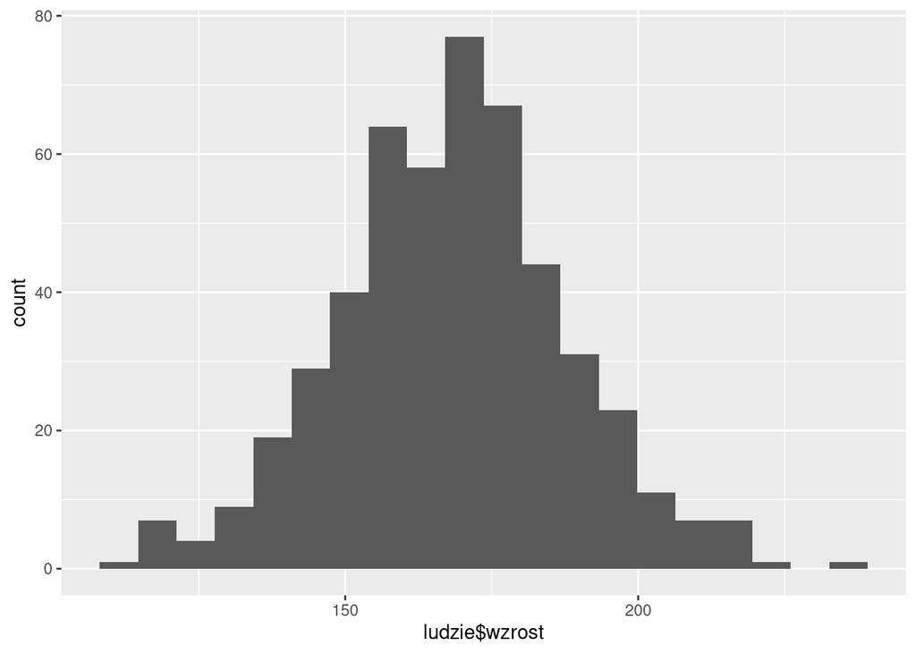

```r
ggplot()+geom_histogram(aes(x=ludzie$wzrost), binwidth = sd(ludzie$wzrost)/3)
```

Jak widać, założenia testu są spełnione.

```r
med0 <- 165
wilcox.test(ludzie$wzrost,  mu = med0, alternative = "l")
```

```
##
##  Wilcoxon signed rank test with continuity correction
##
## data:  ludzie$wzrost
## V = 74416, p-value = 0.9999
## alternative hypothesis: true location is less than 165
```

Otrzymaliśmy p-wartość 0.9999 - otrzymana p-wartość jest niepokojąco wysoka, daje silne poparcie dla hipotezy zerowej. Teraz będziemy testować średnią. Chcielibyśmy posłużyć się testem t-Studenta. Do tego jednak potrzebujemy założenia o normalności rozkładu zmiennej wzrost. Żeby sprawdzić prawdziwość tego założenia posłużymy się wykresem kwantyl-kwantyl.

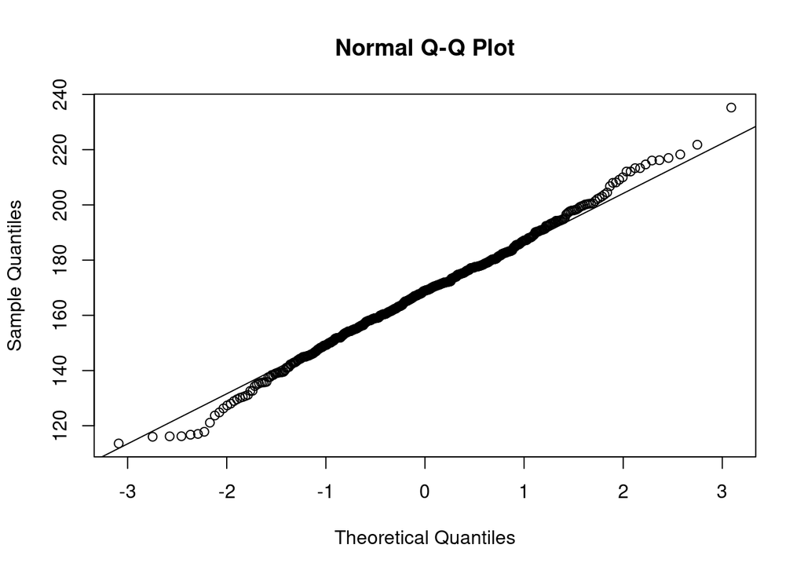

```r
qqnorm(ludzie$wzrost)
qqline(ludzie$wzrost)
```

Widzimy, że poza kilkoma nieznacznie odstającymi obserwacjami możemy uznać nasz rozkład za normalny, jednak te odstępstwa bierzemy pod uwagę przy interpretacji wyników. Naszą hipotezą jest $H_0:m = 170 $ dla zmiennej wzrost przeciwko hipotezie alternatywnej $H_0<170$

```r
sr0 <- 170
t.test(ludzie$wzrost, mu=sr0, alternative = "less")
```

```
##
##  One Sample t-test
##
## data:  ludzie$wzrost
## t = -2.0699, df = 499, p-value = 0.01949
## alternative hypothesis: true mean is less than 170
## 95 percent confidence interval:
##     -Inf 169.629
## sample estimates:
## mean of x
##  168.1804
```

Otrzymaliśmy p-wartość 0.01949 - na poziomie istotności 0.99 nie odrzucilibyśmy hipotezy zerowej, ale na poziomie istotności 0.95 już tak. Biorąc pod uwagę nieznaczne odstępstwa od normalności naszego rozkładu, do otrzymanej p-wartości podchodzimy raczej z dystansem.

**Zadanie 4**

Chcielibyśmy znaleźć przedziały ufności dla zmiennej wiek. Przyjrzyjmy się jej bliżej.

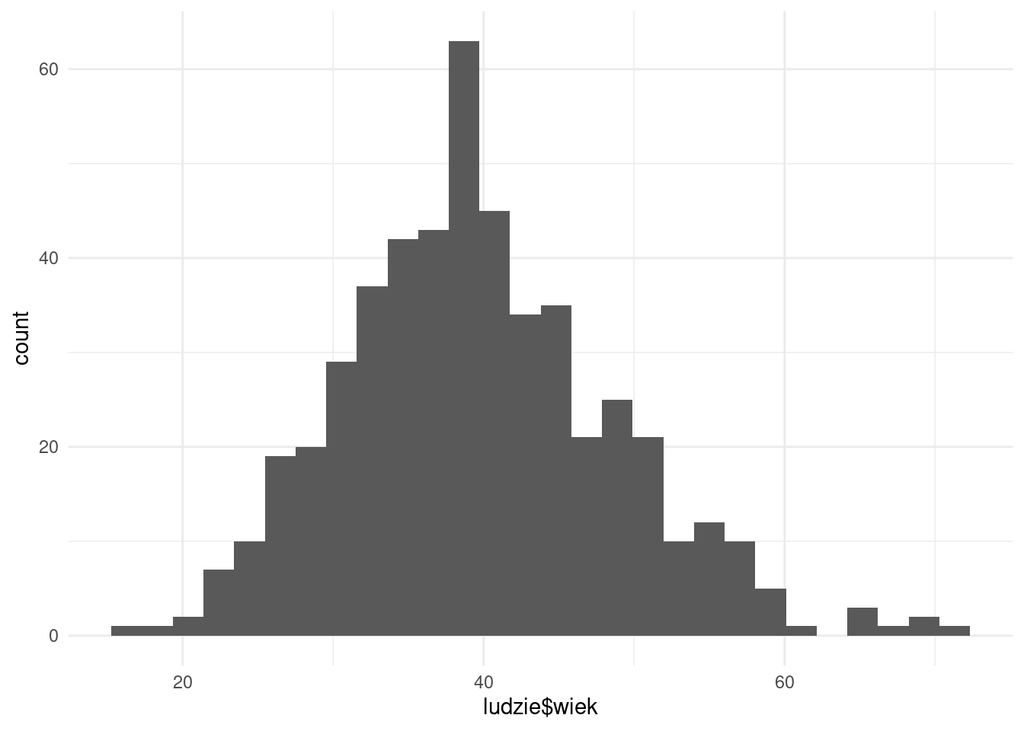

```r
ggplot() + geom_histogram(aes(x=ludzie$wiek), bins=28) +theme_minimal()
```

Otrzymany wykres wskazuje na rozkład w przybliżeniu normalny. Takie założenie bardzo ułatwiłoby nam znalezienie przedziałów, zanim jednak to zrobimy przyjrzyjmy się jeszcze wykresowi kwantyl-kwantyl.

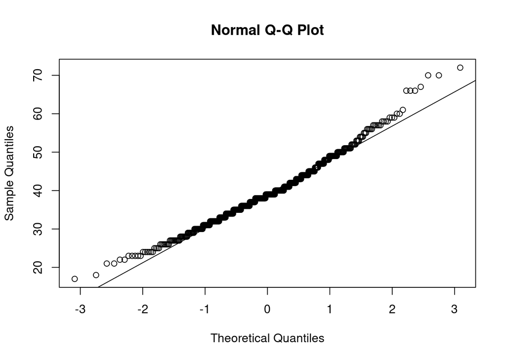

```r
qqnorm(ludzie$wiek)
qqline(ludzie$wiek)
```

Wykresy wskazują, że nasz rozkład można przybliżyć normalnym, pamiętając że im dalej jesteśmy od tego przybliżenia tym bardziej otrzymane przez nas wyniki odbiegały będą od rzeczywistości, gdyż stojąca za nimi teoria nie jest w pełni zgodna z obserwacjami.

```r
t.test(ludzie$wiek, conf.level = 0.99)
```

```
##
##  One Sample t-test
##
## data:  ludzie$wiek
## t = 98.357, df = 499, p-value < 2.2e-16
## alternative hypothesis: true mean is not equal to 0
## 99 percent confidence interval:
##  38.446 40.522
## sample estimates:
## mean of x
##    39.484
```

Otrzymaliśmy przedział ufności (38.446 40.522). Teraz szukamy odchylenia standardowego. Posłużymy się wzorem z wykładu dla nieznanej średniej.

```r
Sn <- sd(ludzie$wiek)^2
N <- length(ludzie$wiek)
alpha <- 0.99
lewy_kwantyl <- qchisq(p=1-alpha/2, df=N-1)
lewy_kraniec <- sqrt(N*Sn/lewy_kwantyl)
prawy_kwantyl <- qchisq(p=alpha/2, df=N-1)
prawy_kraniec <- sqrt(N*Sn/prawy_kwantyl)
lewy_kraniec
```

```
## [1] 8.987781
```

```r
prawy_kraniec
```

```
## [1] 8.994919
```

Otrzymalismy w ten sposób przedział (8.987781, 8.994919) na poziomie 0.99 dla odchylenia standardowego. Teraz zajmiemy się obliczaniem przedziału dla kwantyli. Posłużymy się funkcją quantileCI z biblioteki jmuOutlier.

```r
przedzial_q_1_4 <- quantileCI(ludzie$wiek, probs = 0.25, conf.level = 0.99)
przedzial_q_2_4 <- quantileCI(ludzie$wiek, probs = 0.5, conf.level = 0.99)
przedzial_q_3_4 <- quantileCI(ludzie$wiek, probs = 0.75, conf.level = 0.99)
```

Dla kwantyla 1/4 dostaliśmy przedział

```r
przedzial_q_1_4
```

```
##      lower upper
## 0.25    32    35
```

Dla kwantyla 2/4 dostaliśmy przedział

```r
przedzial_q_2_4
```

```
##     lower upper
## 0.5    38    40
```

Dla kwantyla 3/4 dostaliśmy przedział

```r
przedzial_q_3_4
```

```
##      lower upper
## 0.75    43    47
```

**Zadanie 5**

Będziemy testować hipotezę $H_0: \mu _{wzrost|zamężna/żonaty} = \mu _{wzrost|panna/kawaler}$ przeciwko hipotezie alternatywnej $H_1: \mu _{wzrost|zamężna/żonaty} \neq \mu _{wzrost|panna/kawaler}$. Upewnijmy się raz jeszcze, że zmienna wzrost ma rozkład normalny.

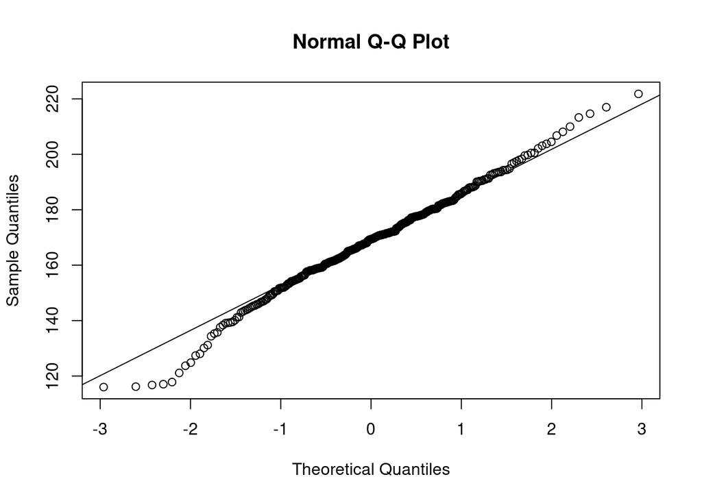

```r
qqnorm(ludzie[which(ludzie$stan_cywilny == FALSE),]$wzrost)
qqline(ludzie[which(ludzie$stan_cywilny == FALSE),]$wzrost)
```

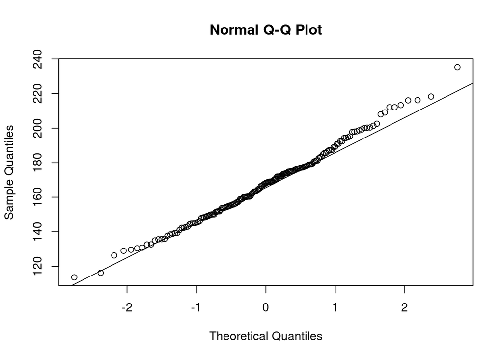

```r
qqnorm(ludzie[which(ludzie$stan_cywilny == TRUE),]$wzrost)
qqline(ludzie[which(ludzie$stan_cywilny == TRUE),]$wzrost)
```

Więc nasze założenia są spełnione, możemy się więc posłużyć testem t-Studenta

```r
t.test(x=ludzie[which(ludzie$stan_cywilny == FALSE),]$wzrost, y=ludzie[which(ludzie$stan_cywilny == TRUE),]$wzrost, df=liczba_singli+liczba_malz-2, paired = FALSE, alternative = "two.sided")
```

```
##
##  Welch Two Sample t-test
##
## data:  ludzie[which(ludzie$stan_cywilny == FALSE), ]$wzrost and ludzie[which(ludzie$stan_cywilny == TRUE), ]$wzrost
## t = 0.43197, df = 302.94, p-value = 0.6661
## alternative hypothesis: true difference in means is not equal to 0
## 95 percent confidence interval:
##  -2.993306  4.677071
## sample estimates:
## mean of x mean of y
##  168.4717  167.6298
```

Otrzymaliśmy p-wartość $0.6661>0.01$ więc nie ma podstaw do odrzucenia hipotezy, że średni wzrost dla osób w związku małżeńskim jest taki sam jak dla osób nie będących w takim związku.

Teraz będziemy testować hipotezę $H_0:$ Wydatki są niezależne od wzrostu przeciwko hipotezie alternatywnej $H_1:$Wydatki są zaleźne od wzrostu. Posłużymy się testem niezaleźności chi-kwadrat.

```r
#hipoteza0 - wydatki nie zaleza od wzrostu
chisq.test(x=ludzie$wydatki, y=ludzie$wzrost)
```

```
##
##  Pearson's Chi-squared test
##
## data:  ludzie$wydatki and ludzie$wzrost
## X-squared = 235500, df = 235056, p-value = 0.2585
```

Dostaliśmy p-wartość $0.2585>0.01$ więc nie ma podstaw do odrzucenia hipotezy zerowej. Możemy nawet przypuszczać, że wydatki nie zależą od wzrostu (Zgodnie z intuicją).

Teraz będziemy testować niezależność stanu cywilnego od płci. Posłużymy się testem dokładnym Fishera.

```r
#hipoteza 0 - stan cywilny nie zalezy od plci
fisher.test(x=ludzie$plec, y=ludzie$stan_cywilny)
```

```
##
##  Fisher's Exact Test for Count Data
##
## data:  ludzie$plec and ludzie$stan_cywilny
## p-value = 0.1179
## alternative hypothesis: true odds ratio is not equal to 1
## 95 percent confidence interval:
##  0.4859847 1.0911057
## sample estimates:
## odds ratio
##  0.7292089
```

Otrzymaliśmy p-wartość $0.1179>0.01$, więc nie ma podstaw do odrzucenia hipotezy zerowej.

Ostatnią hipotezą do przetestowania jest, że waga ma rozkład normalny ze średnią 80. Nie znamy średniej ani odchylenia standardowego, ale widzimy z wykresu że waga ma rozkład bliski normalnemu, więc posłużymy się testem t-Studenta.

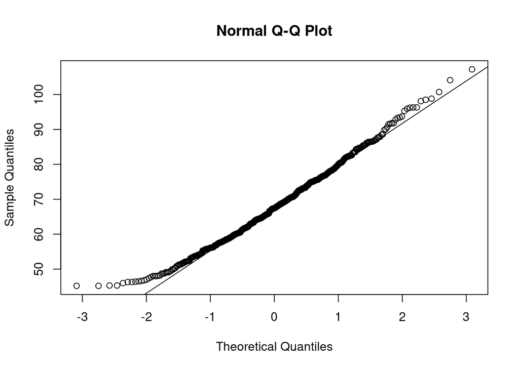

```r
qqnorm(ludzie$waga)
qqline(ludzie$waga)
```

```r
t.test(ludzie$waga, mu=80)
```

```
##
##  One Sample t-test
##
## data:  ludzie$waga
## t = -22.705, df = 499, p-value < 2.2e-16
## alternative hypothesis: true mean is not equal to 80
## 95 percent confidence interval:
##  66.99312 69.06488
## sample estimates:
## mean of x
##    68.029
```

Otrzymaliśmy p-wartość mniejszą niż 0.01, co wskazuje na odrzucenie hipotezy zerowej

**Zadanie 6**

Szacujemy model regresji liniowej. Z wykresów z początku raportu widzimy, że transformacje nie są niezbędne - widzimy albo chmury danych, albo zależności liniowe.

```r
model=lm(ludzie$oszczednosci~ ., data=ludzie)
summary(model)
```

```
##
## Call:
## lm(formula = ludzie$oszczednosci ~ ., data = ludzie)
##
## Residuals:
##     Min      1Q  Median      3Q     Max
## -307.64  -60.13   -1.69   58.06  462.98
##
## Coefficients:
##                        Estimate Std. Error t value Pr(>|t|)
## (Intercept)          -873.59106   58.76098 -14.867  < 2e-16 ***
## wiek                   63.94258    0.56712 112.750  < 2e-16 ***
## waga                    3.94409    0.56935   6.927 1.49e-11 ***
## wzrost                 -2.38464    0.35204  -6.774 3.94e-11 ***
## plecM                   1.38069    9.63179   0.143    0.886
## stan_cywilnyTRUE       -4.61252   12.91187  -0.357    0.721
## liczba_dzieci         151.60355    6.15687  24.623  < 2e-16 ***
## budynekjednorodzinny -182.07031   16.43991 -11.075  < 2e-16 ***
## budynekkamienica     -305.63144   17.89020 -17.084  < 2e-16 ***
## budynekloft          -338.47001   25.14078 -13.463  < 2e-16 ***
## budynekwielka_plyta  -564.26015   20.59225 -27.402  < 2e-16 ***
## wydatki                -0.39593    0.01057 -37.455  < 2e-16 ***
## ---
## Signif. codes:  0 '***' 0.001 '**' 0.01 '*' 0.05 '.' 0.1 ' ' 1
##
## Residual standard error: 102 on 450 degrees of freedom
##   (38 observations deleted due to missingness)
## Multiple R-squared:  0.9673, Adjusted R-squared:  0.9665
## F-statistic:  1209 on 11 and 450 DF,  p-value: < 2.2e-16
```

Niezbędne wyniki widzimy w tabelce powyżej. Teraz będziemy poszukiwać zmiennej, którą z naszego modelu można wyrzucić. Na podstawie p-wartości oraz istotności w modelu pełnym nasuwa się dwóch kandydatów - płeć oraz stan cywilny.

```r
rss <-list()
adjusted_r_kwadrat <- list()
for (i in 1:(length(ludzie)-1))
{
  model_i <- lm(oszczednosci~ ., data=ludzie[-i])
  x <- summary(model_i)
  rss[i] <- x[6]
  adjusted_r_kwadrat[i] <- x[9]

}
```

Otrzymaliśmy

```r
rss
```

```
## [[1]]
## [1] 551.0104
##
## [[2]]
## [1] 107.1765
##
## [[3]]
## [1] 106.9499
##
## [[4]]
## [1] 102.6342
##
## [[5]]
## [1] 101.8962
##
## [[6]]
## [1] 156.0943
##
## [[7]]
## [1] 173.4661
##
## [[8]]
## [1] 206.7363
```

```r
adjusted_r_kwadrat
```

```
## [[1]]
## [1] 0.02118112
##
## [[2]]
## [1] 0.9629676
##
## [[3]]
## [1] 0.963124
##
## [[4]]
## [1] 0.9672882
##
## [[5]]
## [1] 0.9665267
##
## [[6]]
## [1] 0.9214481
##
## [[7]]
## [1] 0.9029911
##
## [[8]]
## [1] 0.8622106
```

$RSS$ jest minimalizowane po usunięciu stanu cywilnego, ale $R^2$ jest maksymalizowane po usunięciu płci. Różnice nie są jednak duże, więc pozwolę sobie jeszcze spojrzeć jak radzi sobie cały model po wyrzuceniu każdego z tych dwóch kandydatów.

```r
model2 <- lm(oszczednosci~ ., data=ludzie[-4])
summary(model2)
```

```
##
## Call:
## lm(formula = oszczednosci ~ ., data = ludzie[-4])
##
## Residuals:
##     Min      1Q  Median      3Q     Max
## -298.13  -63.90   -1.14   57.77  473.28
##
## Coefficients:
##                        Estimate Std. Error t value Pr(>|t|)
## (Intercept)          -8.487e+02  5.618e+01 -15.106  < 2e-16 ***
## wiek                  6.414e+01  5.389e-01 119.018  < 2e-16 ***
## waga                  3.640e+00  5.472e-01   6.652 7.77e-11 ***
## wzrost               -2.356e+00  3.423e-01  -6.881 1.82e-11 ***
## stan_cywilnyTRUE     -4.894e+00  1.236e+01  -0.396    0.692
## liczba_dzieci         1.549e+02  5.899e+00  26.256  < 2e-16 ***
## budynekjednorodzinny -1.854e+02  1.593e+01 -11.640  < 2e-16 ***
## budynekkamienica     -3.090e+02  1.732e+01 -17.836  < 2e-16 ***
## budynekloft          -3.495e+02  2.360e+01 -14.809  < 2e-16 ***
## budynekwielka_plyta  -5.725e+02  1.960e+01 -29.217  < 2e-16 ***
## wydatki              -4.020e-01  9.941e-03 -40.440  < 2e-16 ***
## ---
## Signif. codes:  0 '***' 0.001 '**' 0.01 '*' 0.05 '.' 0.1 ' ' 1
##
## Residual standard error: 102.6 on 489 degrees of freedom
## Multiple R-squared:  0.9679, Adjusted R-squared:  0.9673
## F-statistic:  1477 on 10 and 489 DF,  p-value: < 2.2e-16
```

```r
model2 <- lm(oszczednosci~ ., data=ludzie[-5])
summary(model2)
```

```
##
## Call:
## lm(formula = oszczednosci ~ ., data = ludzie[-5])
##
## Residuals:
##     Min      1Q  Median      3Q     Max
## -307.76  -59.75   -1.38   57.75  462.87
##
## Coefficients:
##                        Estimate Std. Error t value Pr(>|t|)
## (Intercept)          -873.53974   58.70394 -14.880  < 2e-16 ***
## wiek                   63.93900    0.56648 112.870  < 2e-16 ***
## waga                    3.93725    0.56848   6.926 1.50e-11 ***
## wzrost                 -2.38392    0.35169  -6.778 3.82e-11 ***
## plecM                   1.79131    9.55370   0.187    0.851
## liczba_dzieci         150.65024    5.54311  27.178  < 2e-16 ***
## budynekjednorodzinny -181.67008   16.38582 -11.087  < 2e-16 ***
## budynekkamienica     -305.59019   17.87251 -17.098  < 2e-16 ***
## budynekloft          -338.23676   25.10798 -13.471  < 2e-16 ***
## budynekwielka_plyta  -563.72863   20.51856 -27.474  < 2e-16 ***
## wydatki                -0.39599    0.01056 -37.504  < 2e-16 ***
## ---
## Signif. codes:  0 '***' 0.001 '**' 0.01 '*' 0.05 '.' 0.1 ' ' 1
##
## Residual standard error: 101.9 on 451 degrees of freedom
##   (38 observations deleted due to missingness)
## Multiple R-squared:  0.9673, Adjusted R-squared:  0.9665
## F-statistic:  1332 on 10 and 451 DF,  p-value: < 2.2e-16
```

Pierwszy wykres wskazuje, że zależność zmiennej objaśnianej jest rzeczywiście liniowa, więc nasze pierwsze założenie jest spełnionw

```r
resettest(model2, power=2:3, type=c("fitted"))
```

```
##
##  RESET test
##
## data:  model2
## RESET = 2.8561, df1 = 2, df2 = 449, p-value = 0.05854
```

Dostaliśmy p-wartość 0.05854, więc nie ma podstaw by podważać założenie o liniowości badanej zależności.

```r
mean(model2$residuals)
```

```
## [1] -5.699355e-16
```

```r
model_bez_stalej<- lm(oszczednosci ~ . -1, ludzie[-5])
mean(model_bez_stalej$residuals)
```

```
## [1] 8.867366e-16
```

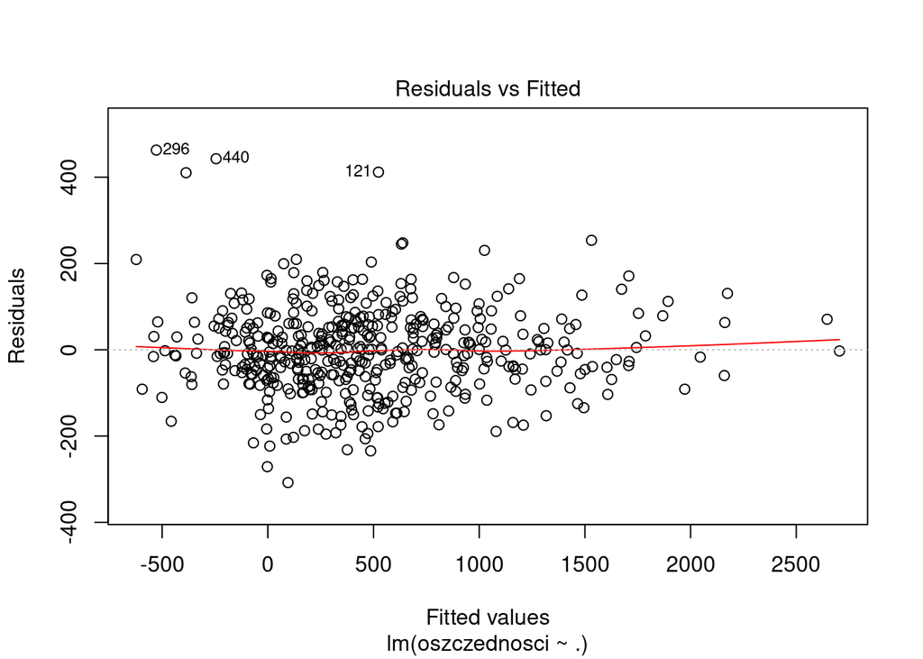

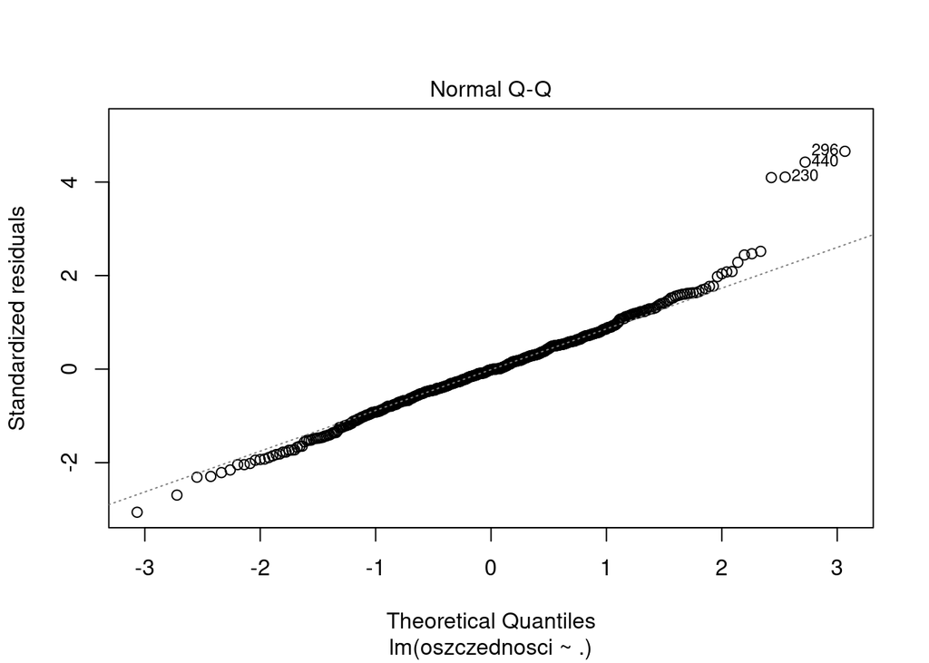

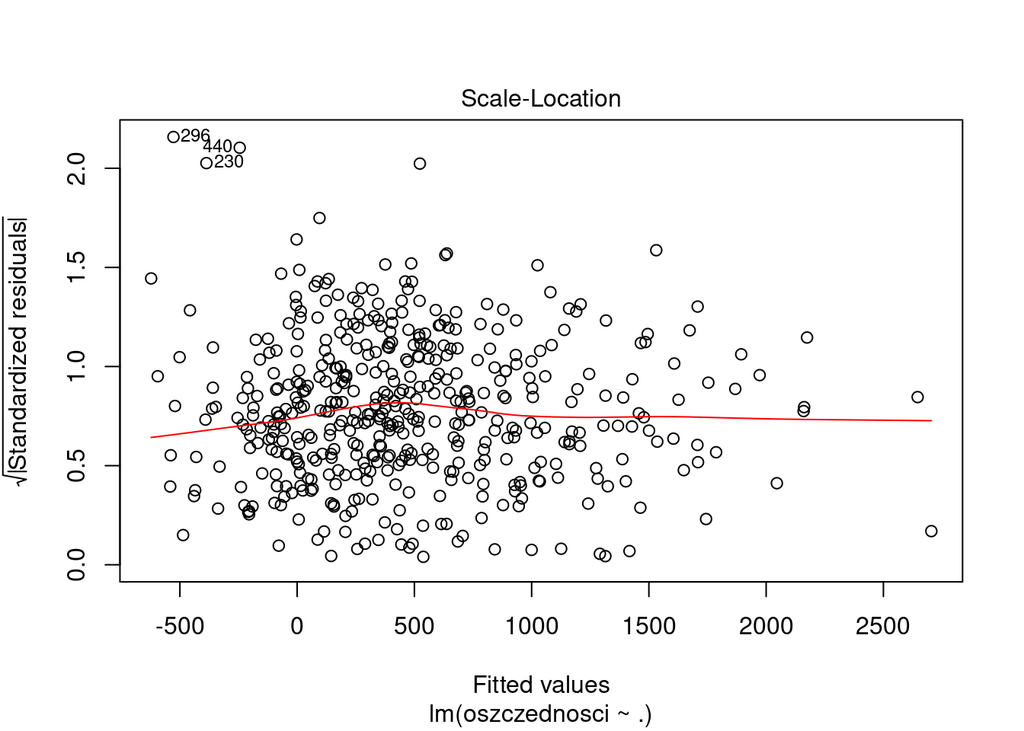

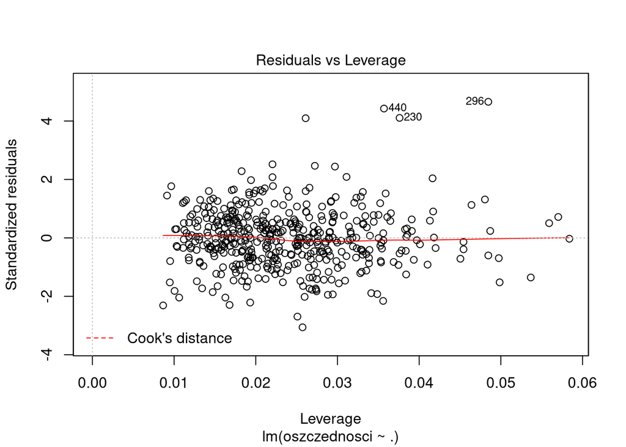

```r
plot(model2)
```

Na podstawie pierwszego wykresu widzimy brak autokorelacji błędów oraz potwierdzamy liniową zależność między zmiennymi.

Na postawie drugiego wykresu widzimy, że poza 4 outlier’ami rozkład błędów jest normalny.

Wykres reszt standaryzowanych wskazuje, że obecna jest homoskedastyczność.

Wykres dźwigni pozwala nam potwierdzić nasze wcześniejsze przypuszczenie o obecności outlier’ów, jednocześnie widzimy że mieszczą się one jednak w dystansie Cook’a.